# Problem Set 3

BUS 696 Problem Set Template

Ryan Richardson

```r
getwd()
```

```
## [1] "E:/Chapman/graduate-work/bs-696-bus-ml/HW3"
```

```r
# load all your libraries in this chunk
library('tidyverse')
library('here')
library('forcats')
library('rsample')
library('plotROC')
library('glmnet')
library('glmnetUtils')
# note, do not run install.packages() inside a code chunk. install them in the console outside of a code chunk.
```

## Question 1

```r
movies <- read.csv(here::here("datasets", "IMDB_movies.csv"))

movies_clean <-
  movies %>%
  mutate(budgetM = budget/1000000,
         grossM = gross/1000000,
         profitM = grossM - budgetM,
         ROI = profitM/budgetM,
         blockbuster = ifelse(profitM > 100, 1,0) %>% factor(., levels = c("1","0")),
         genre_main = as.factor(unlist(map(strsplit(as.character(movies$genres),"\\|"),1))) %>% fct_lump(12),
         rating_simple = fct_lump(content_rating, n = 4)) %>%
  filter(budget < 400000000,
         content_rating != "",
         content_rating != "Not Rated") %>%
  mutate(rating_simple = rating_simple %>% fct_drop()) %>%
  distinct()

movies_split <- initial_split(movies_clean)
movies_train <- training(movies_split)
movies_test <- testing(movies_split)
```

```r
movies_logit1 = glm(blockbuster ~ imdb_score + budgetM + title_year + genre_main, data = movies_train, family="binomial")

summary(movies_logit1)
```

```
##
## Call:
## glm(formula = blockbuster ~ imdb_score + budgetM + title_year +
##     genre_main, family = "binomial", data = movies_train)
##
## Deviance Residuals:
##     Min       1Q   Median       3Q      Max
## -3.4204   0.1256   0.2132   0.3284   1.9250
##
## Coefficients:
##                          Estimate  Std. Error z value
## (Intercept)            -40.544537   15.615660  -2.596
## imdb_score              -1.253443    0.121815 -10.290
## budgetM                 -0.011809    0.001755  -6.729
## title_year               0.026201    0.007720   3.394
## genre_mainAdventure     -0.328119    0.251741  -1.303
## genre_mainAnimation     -0.399023    0.543878  -0.734
## genre_mainBiography      0.834306    0.441878   1.888
## genre_mainComedy        -0.198134    0.275177  -0.720
## genre_mainCrime          1.855428    0.625697   2.965
## genre_mainDocumentary    0.630080    1.066735   0.591
## genre_mainDrama          0.734040    0.318291   2.306
## genre_mainFantasy       14.157876  721.122961   0.020
## genre_mainHorror         0.204078    0.650060   0.314
## genre_mainMystery       14.698878  887.247487   0.017
## genre_mainSci-Fi        15.067106 1330.176066   0.011
## genre_mainOther         -1.479687    1.110588  -1.332
##                                   Pr(>|z|)
## (Intercept)                       0.009421 **
## imdb_score            < 0.0000000000000002 ***
## budgetM                    0.0000000000171 ***
## title_year                        0.000689 ***
## genre_mainAdventure               0.192438
## genre_mainAnimation               0.463154
## genre_mainBiography               0.059014 .
## genre_mainComedy                  0.471510
## genre_mainCrime                   0.003023 **
## genre_mainDocumentary             0.554747
## genre_mainDrama                   0.021100 *
## genre_mainFantasy                 0.984336
## genre_mainHorror                  0.753569
## genre_mainMystery                 0.986782
## genre_mainSci-Fi                  0.990962
## genre_mainOther                   0.182746
## ---
## Signif. codes:  0 '***' 0.001 '**' 0.01 '*' 0.05 '.' 0.1 ' ' 1
##
## (Dispersion parameter for binomial family taken to be 1)
##
##     Null deviance: 1250.47  on 2812  degrees of freedom
## Residual deviance:  967.88  on 2797  degrees of freedom
## AIC: 999.88
##
## Number of Fisher Scoring iterations: 16
```

```r
exp(coef(movies_logit1))
```

```
##                      (Intercept)                       imdb_score
##       0.000000000000000002464513       0.285520136410898961454308
##                          budgetM                       title_year
##       0.988260168879006362097073       1.026547534903866631950109
##              genre_mainAdventure              genre_mainAnimation
##       0.720277248790907598241517       0.670974933798916151062031
##              genre_mainBiography                 genre_mainComedy
##       2.303215364457234404227393       0.820259548303915453359991
##                  genre_mainCrime            genre_mainDocumentary
##       6.394433097540412447301605       1.877761019165545830489350
##                  genre_mainDrama                genre_mainFantasy
##       2.083480728123675351781685 1408274.574595839483663439750671
##                 genre_mainHorror                genre_mainMystery
##       1.226393409785268673317660 2419032.790260541718453168869019
##                 genre_mainSci-Fi                  genre_mainOther
## 3495915.239064668770879507064819       0.227708842094891922291922
```

```r
levels(movies_train$genre_main)
```

```
##  [1] "Action"      "Adventure"   "Animation"   "Biography"
##  [5] "Comedy"      "Crime"       "Documentary" "Drama"
##  [9] "Fantasy"     "Horror"      "Mystery"     "Sci-Fi"
## [13] "Other"
```

1g) The null hypothesis for logistic regression is that there is no relationship between each of the variables we are estimating, and the odds of our output occurring. For example, if we were estimating the probability of a coin flip being heads based on the time of day, the null hypothesis would be that the impact of the time of day on the probability of being heads is 0.

```r
preds_test = predict(movies_logit1, movies_test)
preds_train = predict(movies_logit1, movies_train)
head(preds_test)
```

```
##          3          5          9         15         19         23
##  0.8343241  0.7855752 -0.5874589  0.5167303  0.9919061 -0.6887987
```

```r
head(preds_train)
```

```
##      3363      3152      3198       675      3030      2896
##  7.272796 20.808490  5.385977  2.324397  3.746075  4.341891
```

```r
results_train <- data.frame(
  `truth` = movies_train   %>% select(blockbuster) %>%
    mutate(blockbuster = as.numeric(blockbuster)),
  `Class1` =  preds_train,
  `type` = rep("train",length(preds_train))
)

results_test <- data.frame(
  `truth` = movies_test   %>% select(blockbuster) %>%
    mutate(blockbuster = as.numeric(blockbuster)),
  `Class1` =  preds_test,
  `type` = rep("test",length(preds_test))
)

results <- bind_rows(results_train,results_test)
```

```r
results %>% slice(1:10)
```

| blockbuster | Class1 | type |
| --- | --- | --- |
| 2 | 7.272796 | train |
| 2 | 20.808490 | train |
| 2 | 5.385977 | train |
| 2 | 2.324397 | train |
| 2 | 3.746075 | train |
| 2 | 4.341891 | train |
| 2 | 2.977803 | train |
| 2 | 2.389049 | train |
| 2 | 2.537655 | train |
| 2 | 3.226891 | train |

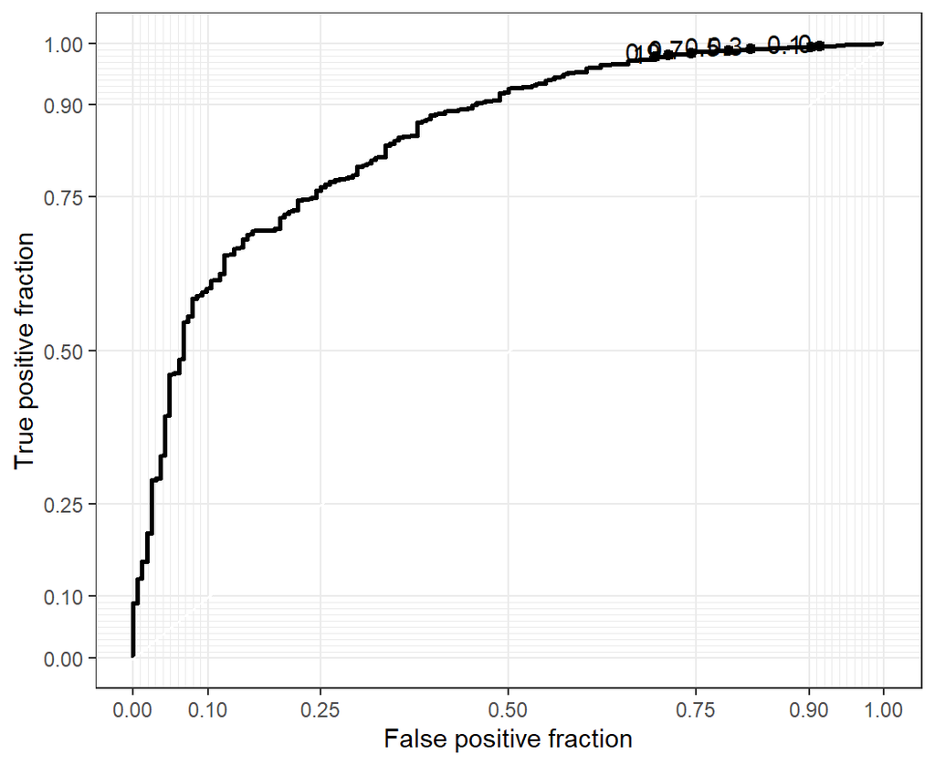

```r
graph_train = ggplot(results_train, aes(d = blockbuster, m = Class1)) + geom_roc(cutoffs.at = c(0.99,0.9,0.7,0.5,0.3,0.1,0)) + style_roc()

graph_test = ggplot(results_test, aes(d = blockbuster, m = Class1)) + geom_roc(cutoffs.at = c(0.99,0.9,0.7,0.5,0.3,0.1,0)) + style_roc()

graph_train
```

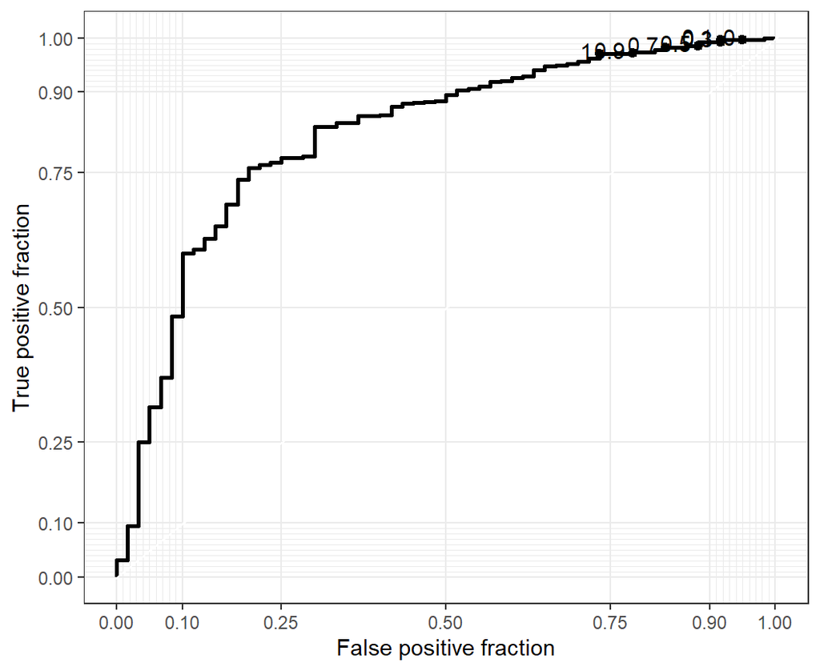

```r
graph_test
```

AUC is a measure of how well our estimates perform across all of the thresholds we could choose for our classification. It’s essentially an estimate of how likely our model is to generate a correct guess, with an AUC of 0.5 being the equivalent of chance.

```r
calc_auc(graph_train)
```

| PANEL | group | AUC |
| --- | --- | --- |
| 1 | -1 | 0.8436179 |

```r
calc_auc(graph_test)
```

| PANEL | group | AUC |
| --- | --- | --- |
| 1 | -1 | 0.8198368 |

## Question 2

```r
ridge_fit = cv.glmnet(grossM ~ duration + rating_simple + aspect_ratio + color + movie_facebook_likes + director_facebook_likes + cast_total_facebook_likes + num_user_for_reviews + num_critic_for_reviews + genre_main, data = movies_train, alpha=0)
```

2b)

```r
coef(ridge_fit)
## 28 x 1 sparse Matrix of class "dgCMatrix"
##                                       s1
## (Intercept)                -3.6195074586
## duration                    0.2236434402
## rating_simpleG             20.6834421749
## rating_simplePG            13.8316123868
## rating_simplePG-13          5.3054648995
## rating_simpleR            -13.5616660976
## rating_simpleOther         -9.8491560710
## aspect_ratio               -1.0975082285
## colorBlack and White       -6.0781837639
## colorColor                  6.0770744160
## movie_facebook_likes        0.0002424305
## director_facebook_likes     0.0004995267
## cast_total_facebook_likes   0.0002090734
## num_user_for_reviews        0.0344597645
## num_critic_for_reviews      0.0776303822
## genre_mainAction            9.5219925209
## genre_mainAdventure        13.0682166568
## genre_mainAnimation        20.0080006178
## genre_mainBiography        -9.5092432286
## genre_mainComedy           -1.4902507323
## genre_mainCrime            -6.6417002413
## genre_mainDocumentary     -10.8836612175
## genre_mainDrama           -11.2693994389
## genre_mainFantasy          -3.9736630564
## genre_mainHorror           -7.3928430056
## genre_mainMystery          -5.3314594288
## genre_mainSci-Fi          -16.1410925024
## genre_mainOther            29.7047765201
```

2c) The plot shows how the mean-squared error changes as we vary our penalization parameter, lambda. The dotted line furthest to the left shows the lambda value that minimizes the mean-squared error of our regression. The second dotted line shows the highest lambda we can choose that is still within 1 standard deviation of the MSE of our lambda with the smallest MSE. We may choose this lambda to reduce the tenancy to over fit. Lastly, the number at the top of the graph shows the amount of non-zero betas in our model. In this case, we always have non-zero betas for all lambdas, which indicates that we are never penalized to the point of excluding any of the coefficients in our model.

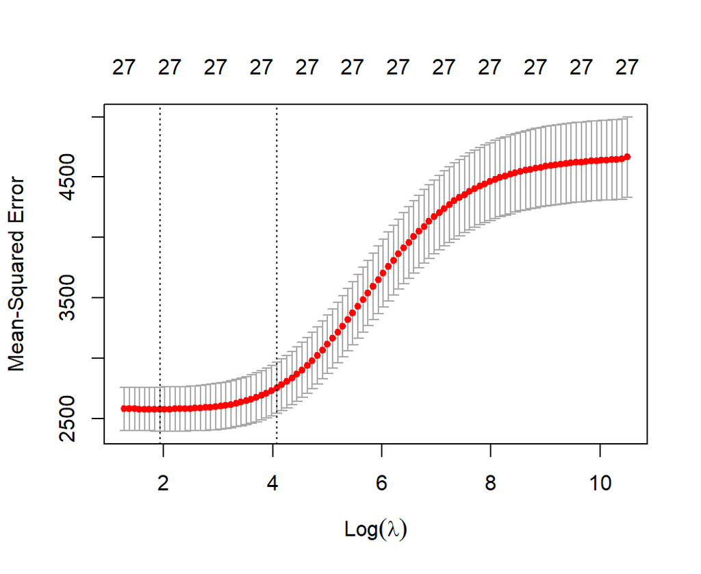

```r
plot(ridge_fit)
```

2d)

```r
lasso_fit = cv.glmnet(grossM ~ duration + rating_simple + aspect_ratio + color + movie_facebook_likes + director_facebook_likes + cast_total_facebook_likes + num_user_for_reviews + num_critic_for_reviews + genre_main, data = movies_train, alpha=1)
```

```r
coef(lasso_fit)
## 28 x 1 sparse Matrix of class "dgCMatrix"
##                                        s1
## (Intercept)                 8.44463685414
## duration                    0.10261637893
## rating_simpleG             14.72147664168
## rating_simplePG            13.43892615557
## rating_simplePG-13          .
## rating_simpleR            -23.95948923421
## rating_simpleOther          .
## aspect_ratio                .
## colorBlack and White       -2.37212851564
## colorColor                  .
## movie_facebook_likes        0.00008493288
## director_facebook_likes     .
## cast_total_facebook_likes   0.00017218989
## num_user_for_reviews        0.05829177948
## num_critic_for_reviews      0.10434506693
## genre_mainAction            7.53433172211
## genre_mainAdventure        10.73112361044
## genre_mainAnimation         4.03044225638
## genre_mainBiography         .
## genre_mainComedy            .
## genre_mainCrime             .
## genre_mainDocumentary       .
## genre_mainDrama            -8.18180003143
## genre_mainFantasy           .
## genre_mainHorror            .
## genre_mainMystery           .
## genre_mainSci-Fi            .
## genre_mainOther             .
```

2f) Lasso regression allows some coefficients to reach 0 as part of the penalization method. This effectively means that their impact on our output was so minimal, that we are able to drop those variables from our model and still have an effective regression.

2g) Similar to the ridge fit, the far left line indicates the lambda that minimizes our MSE, while the next dotted line shows the highest lambda value with an average MSE that is within 1 standard error of the minimum estimate. The numbers at the top of the model show how many non-zero betas are left in the model, and we see that as we increase the penalization factor, more and more betas drop to 0. The plot suggests that we may find a decent model somewhere between 23 and 13 coefficients that has a low MSE and is not too overfit.

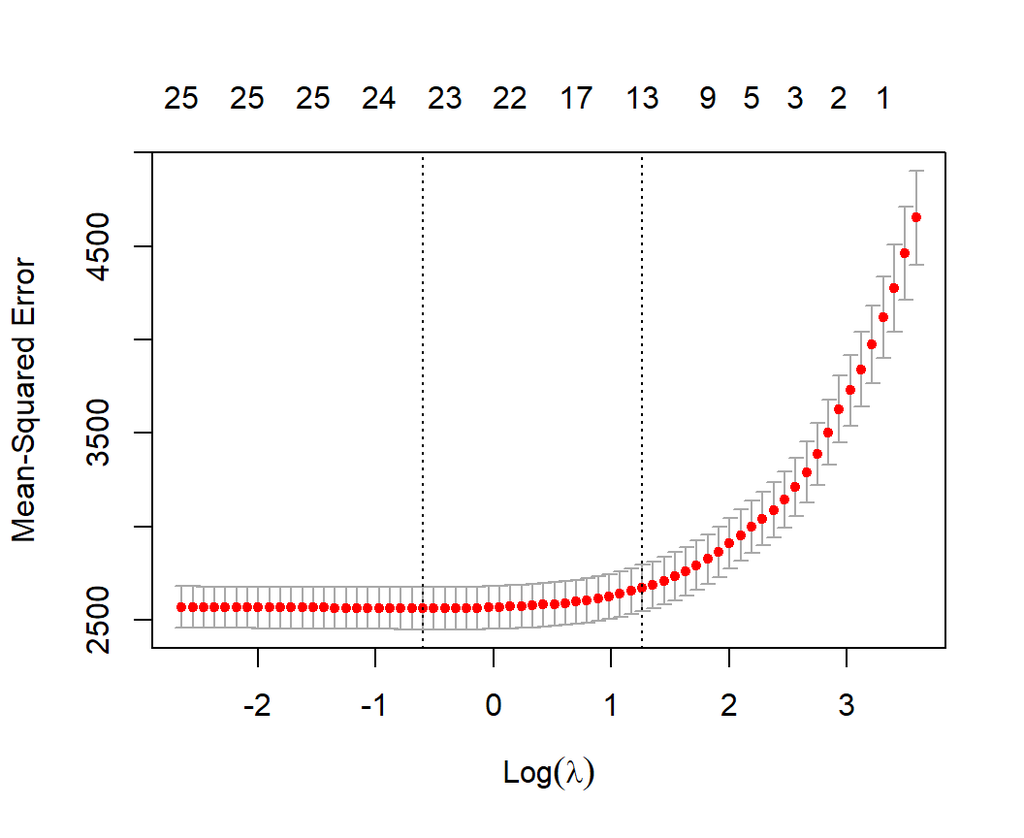

```r
plot(lasso_fit)
```